# 12-09-2014

# Fri-12-Sep-2014: Drawing lines with OCTO data

# Line graphs with OCTO data

The tutorial walks through a simple project in which we import OCTO-TWIN data and learn building line graphs of changes over time.

First, we need to load the packages that will be used during this session.

```r
# Load the necessary packages.
base::require(base)
base::require(knitr)
base::require(markdown)
base::require(testit)
base::require(dplyr)
base::require(reshape2)
base::require(ggplot2)
base::require(sas7bdat)
```

Sometimes, it is useful to declare global objects, to be used throughout the report, like a font size for a collection of plots.

```r
baseSize <- 11
```

### Import the data

Now, we need to locate the data file we would like to work with and bring it into R. Borrowing from epidemiology, we would like to establish a “dataset zero”, a milestone in the workflow of our reproducible project. This dataset, `ds0` represents the state of the data immediately after the import from the secondary source.

```r
pathDir <- getwd()
pathFile <- file.path(pathDir,"Data/Extract/octoall_021114.sas7bdat")
path_ds0 <- file.path(pathDir, "Data/Derived/ds0.Rds")
path_dsL <- file.path("../Data/Derived/dsL.Rds")
# ds0 <- read.sas7bdat(pathFile, debug=TRUE)
# saveRDS(object=ds0, file=path_ds0, compress="xz")
### Either use ds0 definition above or below.
ds0<-readRDS(path_ds0) # This saves time
```

To speed up the execution after the initial import, the file is converted into an native to RStudio **.Rds** file, which could be called in later at a much higher speed than importing from the foreign data source.

### Stages of the dataset

Sometimes it is useful to think of the data preparation process as a series of transformations of data on its way from raw digital records to graph production. We will identify three such stages: original input (ds0), project span (dsL or dsW), and modeling ready (dsM) datasets.

1. Original Input
   - referred to as `ds0`
   - verbatim input from the secondary source, minimum or no processing
   - creates a native (rds) data object
   - “patient zero”
2. Project Span
   - referred to as `dsL` or `dsW`
   - long (L) and wide (W) data formats, respectively
   - subset of ds0
   - what data from the study the project mentions
   - provides richer context
   - invites future research
   - experimentation
3. Modeling ready
   - referred to as `dsM`
   - used in estimating models and graph production
   - subset of dsL + custom data

*. Nameless dataset  
- referred to as `ds` - temporary - used to make code exchangeable

### Basic inspection

```r
class(ds0)
```

```
[1] "data.frame"
```

of the following dimensions ( rows, columns):

```r
dim(ds0)
```

```
[1] 3510  592
```

With so many variables, even such basic function as

```
str(ds0)
```

becomes of little use, as its output floods the console. After identifying the key variables to understand the longitudinal structure of the data, we can select it from the original dataset.

```r
ds <- ds0 %>%
  dplyr::select(PairID, Case, TwinID, Wave, time, CompAge)
head(ds, 6)
```

```
  PairID Case TwinID Wave time CompAge
1     28    1      1    1    0   91.25
2     28    1      1    2  NaN     NaN
3     28    1      1    3  NaN     NaN
4     28    1      1    4  NaN     NaN
5     28    1      1    5  NaN     NaN
6     28    2      2    1    0   91.23
```

- `PairID` - identifies the twin pair.
- `Case` - unique personal identifier
- `Wave` - round of data collection
- `time` - years since the initial measurement
- `CompAge` - composite age in years  
  To that we can add outcomes we’d like to model, the predictors we’d like to test, and other contextual variables. For example,

```r
ds <- ds0 %>%
  dplyr::select(PairID, Case, TwinID, Wave, time, CompAge,prose,sbp, Female)
head(ds, 6)
```

```
  PairID Case TwinID Wave time CompAge prose sbp Female
1     28    1      1    1    0   91.25     3 120      0
2     28    1      1    2  NaN     NaN   NaN NaN      0
3     28    1      1    3  NaN     NaN   NaN NaN      0
4     28    1      1    4  NaN     NaN   NaN NaN      0
5     28    1      1    5  NaN     NaN   NaN NaN      0
6     28    2      2    1    0   91.23     3 120      0
```

### Assign descriptive labels

Variables like `Female` and `Marital` are known as factors: they have only a limited range of categorial values they can take

```r
FemaleLevels<- c(0,1)
FemaleLabels<- c("Male","Female")

varlist<-c("Female")
for(i in varlist){
  ds0[,paste0(i,"F")]<-ordered(ds0[,i],
                               levels = FemaleLevels,
                               labels = FemaleLabels)
}
```

Instead of replacing the existing variable, we create a double, marked by ending “F” for “FACTOR. It is typically useful to have quick access to both raw and labelled data.

```r
ds <- ds0 %>%
  dplyr::select(PairID, Case, TwinID, Wave, time, CompAge,prose,sbp, Female, FemaleF)
head(ds, 6)
```

```
  PairID Case TwinID Wave time CompAge prose sbp Female FemaleF
1     28    1      1    1    0   91.25     3 120      0    Male
2     28    1      1    2  NaN     NaN   NaN NaN      0    Male
3     28    1      1    3  NaN     NaN   NaN NaN      0    Male
4     28    1      1    4  NaN     NaN   NaN NaN      0    Male
5     28    1      1    5  NaN     NaN   NaN NaN      0    Male
6     28    2      2    1    0   91.23     3 120      0    Male
```

### Span and modeling ready sets

We establish what variables should be in quick access and are likely to be used in the project. These variables are assembled in the dataset `dsL`.

```r
dsL <- ds0 %>%
  dplyr::select(Case, PairID, TwinID, Wave, time,
    BirthDate, DeadDate, CompAge, Female, FemaleF, Marital,  # demographic
    weight, height, bmi, # physical
    prose, synnum, # cognitive
    demsev, demsyn, DemAge, # dementia
    diabYN, # diabetes
    sbp,HTyn,HTyn1:HTyn5, # hypertension
    SRhlth, SRhlth1:SRhlth5  # self-reported health
    )
```

However, even this file is too big to be convenient for purposes of graph production and statistical modeling. We subset a more compact dataset, and might augment it with service variables if needed for modeling or graphing.

```r
dsM <- dsL %>%
  dplyr::filter(ave((!is.na(CompAge)), PairID, FUN = all)) %>% # select only cases with nonmissing values
  dplyr::select(PairID, Case, TwinID, Wave, time, CompAge, bmi, weight, sbp, prose, Female, FemaleF)
head(dsM)
```

```
  PairID Case TwinID Wave  time CompAge   bmi weight sbp prose Female FemaleF
1    915   49      1    1 0.000   87.32 23.38     66 150   NaN      0    Male
2    915   49      1    2 2.249   89.57   NaN    NaN NaN   NaN      0    Male
3    915   49      1    3 4.260   91.58 24.91     67 140   NaN      0    Male
4    915   49      1    4 6.173   93.50   NaN    NaN NaN   NaN      0    Male
5    915   49      1    5 8.126   95.45 22.04     60 120   NaN      0    Male
6    915   50      2    1 0.000   87.33 25.56     73 140   NaN      0    Male
```

Now that the dataset is more managable, we can get some descriptive statistics. Two funtions are particularly useful:

```r
base::summary(dsM)
```

```
     PairID          Case         TwinID         Wave        time         CompAge          bmi           weight
 Min.   : 915   Min.   : 49   Min.   :1.0   Min.   :1   Min.   :0.00   Min.   :79.4   Min.   :15.2   Min.   :35.0
 1st Qu.:2407   1st Qu.:268   1st Qu.:1.0   1st Qu.:2   1st Qu.:2.00   1st Qu.:83.7   1st Qu.:21.6   1st Qu.:53.0
 Median :3137   Median :416   Median :1.5   Median :3   Median :4.06   Median :86.5   Median :24.1   Median :60.0
 Mean   :3014   Mean   :410   Mean   :1.5   Mean   :3   Mean   :4.05   Mean   :86.5   Mean   :24.5   Mean   :61.2
 3rd Qu.:3613   3rd Qu.:543   3rd Qu.:2.0   3rd Qu.:4   3rd Qu.:6.17   3rd Qu.:89.0   3rd Qu.:26.8   3rd Qu.:69.8
 Max.   :4254   Max.   :684   Max.   :2.0   Max.   :5   Max.   :8.43   Max.   :95.5   Max.   :41.1   Max.   :95.0
                                                                                      NA's   :36     NA's   :20
      sbp          prose          Female        FemaleF
 Min.   : 90   Min.   : 0.0   Min.   :0.000   Male  : 90
 1st Qu.:140   1st Qu.: 9.0   1st Qu.:1.000   Female:340
 Median :150   Median :12.0   Median :1.000
 Mean   :153   Mean   :10.3   Mean   :0.791
 3rd Qu.:160   3rd Qu.:13.0   3rd Qu.:1.000
 Max.   :260   Max.   :16.0   Max.   :1.000
 NA's   :8     NA's   :96
```

```r
# and

psych::describe(dsM)
```

```
         vars   n      mean       sd   median   trimmed      mad    min      max    range     skew kurtosis       se
PairID      1 430 3014.0000 803.6795 3137.000 3074.0116 830.2560 915.00 4254.000 3339.000 -0.63803 -0.31280 38.75687
Case        2 430  409.8721 171.3158  415.500  417.1919 190.5141  49.00  684.000  635.000 -0.32125 -0.96553  8.26158
TwinID      3 430    1.5000   0.5006    1.500    1.5000   0.7413   1.00    2.000    1.000  0.00000 -2.00465  0.02414
Wave        4 430    3.0000   1.4159    3.000    3.0000   1.4826   1.00    5.000    4.000  0.00000 -1.30790  0.06828
time        5 430    4.0502   2.8438    4.059    4.0442   3.0710   0.00    8.427    8.427 -0.02027 -1.29804  0.13714
CompAge     6 430   86.4836   3.5046   86.554   86.3933   3.9458  79.37   95.458   16.088  0.20040 -0.55270  0.16901
bmi         7 394   24.4919   4.0290   24.135   24.3227   3.9097  15.24   41.118   25.877  0.54786  0.62745  0.20298
weight      8 410   61.2073  11.2077   60.000   60.9512  11.8608  35.00   95.000   60.000  0.24364 -0.34238  0.55351
sbp         9 422  152.6185  24.3139  150.000  151.0947  14.8260  90.00  260.000  170.000  0.95702  2.21738  1.18358
prose      10 334   10.3473   3.9317   12.000   10.8470   2.9652   0.00   16.000   16.000 -1.03149  0.30772  0.21514
Female     11 430    0.7907   0.4073    1.000    0.8634   0.0000   0.00    1.000    1.000 -1.42417  0.02835  0.01964
FemaleF*   12 430    1.7907   0.4073    2.000    1.8634   0.0000   1.00    2.000    1.000 -1.42417  0.02835  0.01964
```

### Developing line graphs

Now, imaging that you are loading a fresh RStudio session, with Hypertension and Cognition project open.

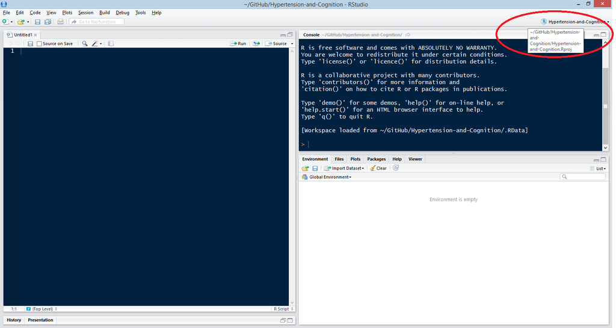

### Data Geneology

A graph or a model is meaningful only to the degree that the data being manifested is meaningful. Understanding the precise origin of your data, therefore, is a key component in construction of any graph. To simplify the exposition of this geneology we have introduced three data stages (see above). This section walks the path from the initiation of R session to the declaration of the data geneology immediately before the graph.

Imaging that you are loading a fresh RStudio session, with Hypertension and Cognition project open.

[figure not shown]

```
./Scripts/Templates/explore-dsL.R
```

which has the following as default text:

```r
# remove all elements for a clean start
rm(list=ls(all=TRUE))

## @knitr LoadPackages
# Load packages to use
base::require(base)
base::require(knitr)
base::require(markdown)
base::require(testit)
base::require(dplyr)
base::require(reshape2)
base::require(ggplot2)
base::require(sas7bdat)

## @knitr LoadData
# run the scripot that loads ds0 and dsL data stages.
source(file.path(getwd(),"Scripts/Data/dsL.R"))
rm(list=setdiff(ls(), c("ds0", "dsL"))) # remove all objects except

## @knitr FirstLook
dim(ds0)
dim(dsL)
str(dsL)

## @knitr DefinedsM
# define the modeling ready dataset
```

Although we might use **dsL** as the datasource in the production of descriptive statistics, production of graphs and estimation of models frequently asks for modifications and augmentations of the data in order to serve particular tactical needs. Therefore we created and work with a disposable datastage **dsM** which is a direct derivation of **dsL**.

```r
dsM <- dsL %>%
  dplyr::filter(ave((!is.na(CompAge)), PairID, FUN = all)) %>% # select only cases with nonmissing values
  dplyr::select(PairID, Case, TwinID, Wave, time, CompAge, bmi, weight, sbp, prose, Female, FemaleF)
```

```r
dsM <- dsL %>% # parent
  dplyr::group_by(PairID) %>% # new unit: groups of obs with same PairID
  dplyr::filter(CompAge=all(!is.na(CompAge))) %>% # select units, in which every value is not(!) missing (is.na) for ComAge variable
  dplyr::select(PairID, Case, TwinID, Wave, time, CompAge, bmi, weight, sbp, prose, FemaleF) # select these variables
dim(dsM) # dimensions (rows, columns)
```

```
[1] 430  11
```

(For other ways of subsetting based on group condition see [this StackOverflow post](http://stackoverflow.com/questions/24583152/how-to-remove-groups-of-observation-with-dplyrfilter))

The origin of the dataset `dsL` has already been provided, therefore the above `dplyr` call is all that is necessary to offer the precise definition of the data. Every graph and model is expected to provide the account of such geneology.

### Practicum: Developing Line Graphs

```r
p <- ggplot2::ggplot(data=dsM,
                aes(x=CompAge,y=sbp, group=Case))
p <- p + geom_line()
p
```

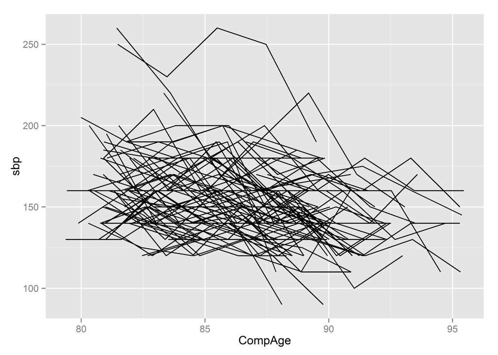

[figure not shown]

```r
themeLine <- ggplot2::theme_bw(base_size=baseSize) +
ggplot2::theme(title=ggplot2::element_text(colour="gray20",size = baseSize+1)) +
ggplot2::theme(axis.text=ggplot2::element_text(colour="gray40")) +
ggplot2::theme(axis.title=ggplot2::element_text(colour="gray40")) +
ggplot2::theme(panel.border = ggplot2::element_rect(colour="gray80")) +
ggplot2::theme(axis.ticks.length = grid::unit(0, "cm")) +
ggplot2::theme(text = element_text(size =baseSize+7))



dsM$TwinID <- factor(dsM$TwinID)
p <- ggplot2::ggplot(data=dsM,
                aes(x=CompAge,y=sbp, group=Case, color=TwinID))
p <- p + geom_line()
p <- p + geom_point()
p <- p + themeLine
p <- p + labs(title="Dynamics of BP over time",
              x="Age of Respondent",
              y="Systolic Blood pressure")
p <- p + facet_grid(FemaleF  ~ TwinID)
p
```

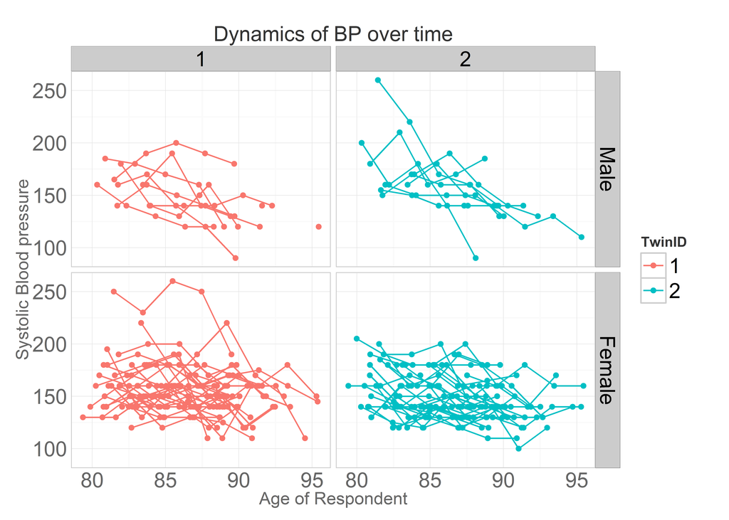

```r
### Consider the following options to further customize your graphs.
# # geoms
# p <- p + geom_line(aes(x=,y=),colour="red",alpha=.5,size=2, na.rm=T)
# p <- p + geom_line(aes(y=), fill=NA, na.rm=T)
# # scales & coordinates
# p <- p + scale_x_continuous(breaks=c(0:15))
# p <- p + scale_y_continuous(breaks=seq(0, 8, 1))
# p <- p + coord_cartesian(xlim=c(-.5, 15.5), ylim=c(.5, 8.5))
#
```